# Practical Machine Learning: Qualitative Activity Recognition of Weight Lifting Exercises

Ken Wade

June 10, 2016

# Executive Summary

Using devices such as Jawbone Up, Nike FuelBand, and Fitbit it is now possible to collect a large amount of data about personal activity relatively inexpensively. These type of devices are part of the quantified self movement - a group of enthusiasts who take measurements about themselves regularly to improve their health, to find patterns in their behavior, or because they are tech geeks. One thing that people regularly do is quantify how much of a particular activity they do, but they rarely quantify how well they do it. In this project, your goal will be to use data from accelerometers on the belt, forearm, arm, and dumbell of 6 participants. They were asked to perform barbell lifts correctly and incorrectly in 5 different ways. More information is available from the website here: http://groupware.les.inf.puc-rio.br/har (see the section on the Weight Lifting Exercise Dataset).

### Course Project Prediction Quiz Portion

Apply your machine learning algorithm to the 20 test cases available in the test data above and submit your predictions in appropriate format to the Course Project Prediction Quiz for automated grading.

### The training data for this project are available here:

https://d396qusza40orc.cloudfront.net/predmachlearn/pml-training.csv

### The test data are available here:

https://d396qusza40orc.cloudfront.net/predmachlearn/pml-testing.csv

### Data Source Citation

WLE Velloso, E.; Bulling, A.; Gellersen, H.; Ugulino, W.; Fuks, H. Qualitative Activity Recognition of Weight Lifting Exercises. Proceedings of 4th International Conference in Cooperation with SIGCHI (Augmented Human ’13). Stuttgart, Germany: ACM SIGCHI, 2013.

# Exploratory Data Analysis

The first thing to do is to setup the program and read the data. If the Weight Lifting Exercises data is not loaded onto the computer already it is setup and downloaded.

### Set up and Read Data

```r
library(caret)
```

```r
library(corrplot)
library(tree)
library(adabag)
set.seed(4242)
setwd("C:/Users/Ken/Documents/Ken/Continuing Education/Johns Hopkins School of Public Health - Data Science 8 - Practical Machine Learning")

data.FolderName        <- "data"
Training.dataURL       <- "https://d396qusza40orc.cloudfront.net/predmachlearn/pml-training.csv"
Training.dataFileName  <-                                                     "pml-training.csv"
Testing.dataURL        <- "https://d396qusza40orc.cloudfront.net/predmachlearn/pml-testing.csv"
Testing.dataFileName   <-                                                     "pml-testing.csv"

# Create the data folder
if(!file.exists(data.FolderName)) {
  dir.create(data.FolderName)
  print(paste("Created ", data.FolderName, " folder.", sep=""))
}

if (!file.exists(paste("./", data.FolderName, "/", Training.dataFileName, sep=""))) {
  print(paste("Downloading Training Data at: ", Training.dataURL, "...", sep=""))
  download.file(Training.dataURL, destfile = paste("./", data.FolderName, "/",Training.dataFileName, sep=""), method="auto")
  print(paste("Downloading ", Training.dataURL, " completed.", sep=""))
}

if (!file.exists(paste("./", data.FolderName, "/", Testing.dataFileName, sep=""))) {
  print(paste("Downloading Testing Data at: ", Testing.dataURL, "...", sep=""))
  download.file(Testing.dataURL, destfile = paste("./", data.FolderName, "/",Testing.dataFileName, sep=""), method="auto")
  print(paste("Downloading ", Testing.dataURL, " completed.", sep=""))
}

# Read the data
Orig.TrainingData <- read.csv(paste("./", data.FolderName, "/", Training.dataFileName, sep=""), header=TRUE)
Orig.TestingData <- read.csv(paste("./", data.FolderName, "/", Testing.dataFileName, sep=""), header=TRUE)

dim(Orig.TrainingData)
```

```
## [1] 19622   160
```

```r
dim(Orig.TestingData)
```

```
## [1]  20 160
```

# Clean the Training Data

There are many columns in the Weight Lifting Exercises data that contain no usable values. The first thing to do is to clean out these columns. The columns to remove are the identification columns, the columns with no data, the columns with unvarying data, and the columns that are highly correlated with another column. The final action is to make all the columns in the testing data match the training data.

```r
# Get rid of identification columns
WorkingData <- subset(Orig.TrainingData, select=
     -c(X, user_name, raw_timestamp_part_1, raw_timestamp_part_2, cvtd_timestamp, new_window, num_window))
dim(WorkingData)
```

```
## [1] 19622   153
```

```r
# Get rid of NA columns
WorkingData <- WorkingData[, sapply(WorkingData, function(x) !(any(is.na(x))))]
dim(WorkingData)
```

```
## [1] 19622    86
```

```r
# Get rid of Uninteresting columns
NZV <- nearZeroVar(WorkingData)
if (length(NZV) > 0) WorkingData <- WorkingData[, -NZV]
dim(WorkingData)
```

```
## [1] 19622    53
```

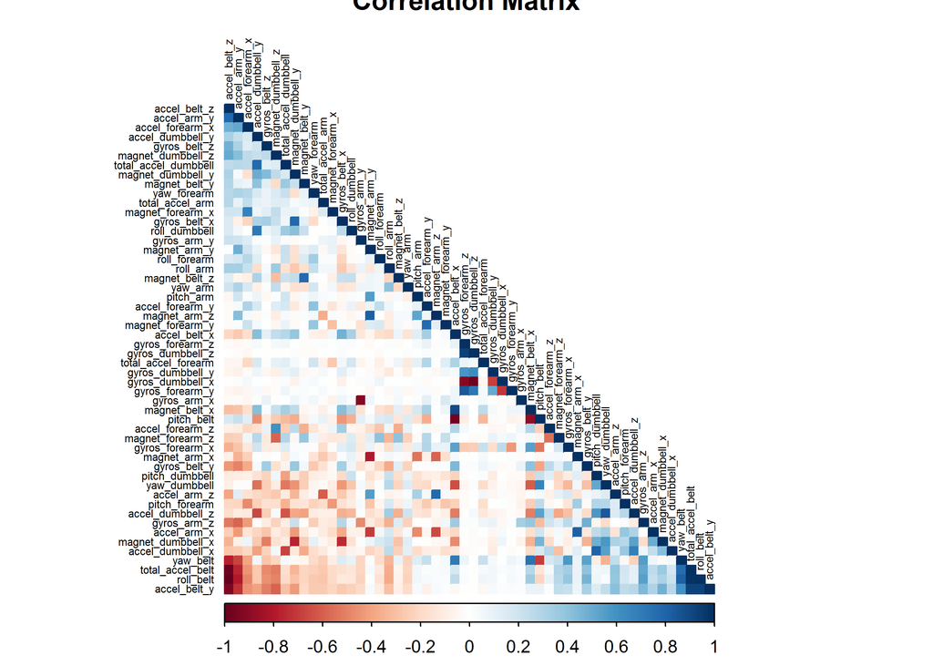

```r
# Get rid of highly correlated columns
corMatrix <- cor(WorkingData[, -match("classe", names(WorkingData))])
corrplot(corMatrix, order = "FPC", method = "color", type = "lower",
         tl.cex = 0.5, tl.col = "black", title = "Correlation Matrix")
```

```r
hiCor <- findCorrelation(corMatrix, cutoff=0.80)
WorkingData <- WorkingData[, -hiCor]
dim(WorkingData)
```

```
## [1] 19622    40
```

```r
# Select only the same columns for the test data
names(Orig.TestingData)[names(Orig.TestingData) == "problem_id"] <- "classe"
Orig.TestingData <- subset(Orig.TestingData, select=names(WorkingData))
```

In the graph above the degree of correlation between the original data values are shown. Of interest are the lighter correlations showing that the two variables in question are less correlated, that is to say, the correlation coefficient is closer to zero.

This data cleaning has resulted in the reduction in the Weight Lifting Exercises data variables from 160 variables down to 40 variables.

# Modeling and Detailed Analysis

It is now possible to develop the actual model for use in this project. The original plan was to use a Random Forest Model using all the columns of data available in the Weight Lifting Exercises data. However, this model never ran to completion. Therefore, three much simpler models were used and compared:

- Tree Model
- rpart Model
- Reduced Variable rpart Model via boosting

```r
# Partition Reduced Training Data (WorkingData) into Testing and Training Data
inTrain <- createDataPartition(y=WorkingData$classe, p=0.8, list=FALSE)
Training <- WorkingData[inTrain, ]
Testing <- WorkingData[-inTrain, ]
dim(Training)
```

```
## [1] 15699    40
```

```r
dim(Testing)
```

```
## [1] 3923   40
```

```r
# Train Tree Model
modFit.Tree=tree(classe~.,data=Training)
# Train rpart Model
modFit.rpart = rpart(classe~., data=Training)

#Radically Reduced rpart Model
Boost <- boosting(classe~., data = Training, mfinal = 10)
Boost.names <- c(names(head(sort(-Boost$importance), 10)), "classe")
Boost.Training <- subset(Training, select=Boost.names)
modFit.Boost <- rpart(classe~., data=Boost.Training)
```

# Predict the results on the Testing Data to make an estimate of out of sample error for each of the models

Using the testing data portion of the original training data the predictions of each of the model are calculated.

```r
# Tree: Predict the results on the Testing Data to make an estimate of out of sample error
pred.Tree <- predict(modFit.Tree, newdata=Testing, type="class")
conMat.Tree <- confusionMatrix(pred.Tree, Testing$classe)
conMat.Tree
```

```
## Confusion Matrix and Statistics
##
##           Reference
## Prediction    A    B    C    D    E
##          A 1028  119   15   49   68
##          B   42  362   68   38  224
##          C   14  112  465   47  144
##          D   32  166  136  509   47
##          E    0    0    0    0  238
##
## Overall Statistics
##
##                Accuracy : 0.6633
##                  95% CI : (0.6482, 0.6781)
##     No Information Rate : 0.2845
##     P-Value [Acc > NIR] : < 2.2e-16
##
##                   Kappa : 0.5727
##  Mcnemar's Test P-Value : < 2.2e-16
##
## Statistics by Class:
##
##                      Class: A Class: B Class: C Class: D Class: E
## Sensitivity            0.9211  0.47694   0.6798   0.7916  0.33010
## Specificity            0.9106  0.88243   0.9021   0.8838  1.00000
## Pos Pred Value         0.8038  0.49319   0.5946   0.5719  1.00000
## Neg Pred Value         0.9667  0.87551   0.9303   0.9558  0.86893
## Prevalence             0.2845  0.19347   0.1744   0.1639  0.18379
## Detection Rate         0.2620  0.09228   0.1185   0.1297  0.06067
## Detection Prevalence   0.3260  0.18710   0.1993   0.2269  0.06067
## Balanced Accuracy      0.9159  0.67969   0.7910   0.8377  0.66505
```

```r
# rpart: Predict the results on the Testing Data to make an estimate of out of sample error
pred.rpart <- predict(modFit.rpart, newdata=Testing, type="class")
conMat.rpart <- confusionMatrix(pred.rpart, Testing$classe)
conMat.rpart
```

```
## Confusion Matrix and Statistics
##
##           Reference
## Prediction    A    B    C    D    E
##          A 1012  107   34   49   50
##          B   45  323   23   67   98
##          C   24  180  550   99  133
##          D   31   72   29  377   47
##          E    4   77   48   51  393
##
## Overall Statistics
##
##                Accuracy : 0.6768
##                  95% CI : (0.6619, 0.6914)
##     No Information Rate : 0.2845
##     P-Value [Acc > NIR] : < 2.2e-16
##
##                   Kappa : 0.5898
##  Mcnemar's Test P-Value : < 2.2e-16
##
## Statistics by Class:
##
##                      Class: A Class: B Class: C Class: D Class: E
## Sensitivity            0.9068  0.42556   0.8041   0.5863   0.5451
## Specificity            0.9145  0.92636   0.8654   0.9454   0.9438
## Pos Pred Value         0.8083  0.58094   0.5578   0.6781   0.6859
## Neg Pred Value         0.9611  0.87051   0.9544   0.9210   0.9021
## Prevalence             0.2845  0.19347   0.1744   0.1639   0.1838
## Detection Rate         0.2580  0.08233   0.1402   0.0961   0.1002
## Detection Prevalence   0.3191  0.14173   0.2513   0.1417   0.1461
## Balanced Accuracy      0.9107  0.67596   0.8347   0.7659   0.7444
```

```r
#  Reduced rpart: Predict the results on the Testing Data to make an estimate of out of sample error
pred.Boost <- predict(modFit.Boost, newdata=Testing, type="class")
conMat.Boost <- confusionMatrix(pred.Boost, Testing$classe)
conMat.Boost
```

```
## Confusion Matrix and Statistics
##
##           Reference
## Prediction   A   B   C   D   E
##          A 965 118  18  39  69
##          B  48 446  74  77 182
##          C  44  88 535  98 128
##          D  38  71  55 417  29
##          E  21  36   2  12 313
##
## Overall Statistics
##
##                Accuracy : 0.6821
##                  95% CI : (0.6673, 0.6967)
##     No Information Rate : 0.2845
##     P-Value [Acc > NIR] : < 2.2e-16
##
##                   Kappa : 0.5968
##  Mcnemar's Test P-Value : < 2.2e-16
##
## Statistics by Class:
##
##                      Class: A Class: B Class: C Class: D Class: E
## Sensitivity            0.8647   0.5876   0.7822   0.6485  0.43412
## Specificity            0.9131   0.8796   0.8895   0.9412  0.97783
## Pos Pred Value         0.7982   0.5393   0.5991   0.6836  0.81510
## Neg Pred Value         0.9444   0.8989   0.9508   0.9318  0.88471
## Prevalence             0.2845   0.1935   0.1744   0.1639  0.18379
## Detection Rate         0.2460   0.1137   0.1364   0.1063  0.07979
## Detection Prevalence   0.3082   0.2108   0.2276   0.1555  0.09788
## Balanced Accuracy      0.8889   0.7336   0.8358   0.7948  0.70597
```

# Conclusion

Large, advanced models take considerable time to process and, therefore, are beyond the capacity of computing resources here. Of the simpler models tested the “boosted rpart” performed best with an overall accuracy of 0.682131. This equates to an out of sample error rate of 31.7868978%. This is not as high an accuracy as hoped for but the best that computing resources allow.

# 20 Answers for Quiz

The following are the answers for the Course Quiz test data:

```r
predQuiz.Tree <- predict(modFit.Tree, newdata= Orig.TestingData, type="class")
predQuiz.Tree
```

```
##  [1] D A C A A C D D A A C C B A C A A D D B
## Levels: A B C D E
```

```r
predQuiz.rpart <- predict(modFit.rpart, newdata= Orig.TestingData, type="class")
predQuiz.rpart
```

```
##  1  2  3  4  5  6  7  8  9 10 11 12 13 14 15 16 17 18 19 20
##  C  A  C  A  A  C  D  D  A  A  E  E  E  A  E  A  A  B  B  E
## Levels: A B C D E
```

```r
predQuiz.Boost <- predict(modFit.Boost, newdata= Orig.TestingData, type="class")
predQuiz.Boost
```

```
##  1  2  3  4  5  6  7  8  9 10 11 12 13 14 15 16 17 18 19 20
##  C  A  B  C  A  C  D  D  A  A  C  B  A  A  D  E  A  B  B  B
## Levels: A B C D E
```